# An anti-inflammatory response of an organic food intervention treatment by reducing pesticide exposures in children of Cyprus: a cluster-randomized crossover trial - Part 1

The script was adapted by the script prepared by Corina Konstantinou and Xanthi Andrianou for the statistical analysis of the cluster-randomized crossover trial of organic diet for primary school children, conducted within the EU LIFE+ programme funded project Organiko in Cyprus (Makris et al., 2019).

This script includes Part 1 of the analysis (descriptives, description of the change in biomarker levels) and the dataset that will be the input of Part 2 of the analysis.

### Table 1 A - Demographic characteristics - Study participants

Demographic & other characteristics of participants with >=12 days in the organic phase

|  | Overall |
| --- | --- |
| n | 149 |
| Group1 = First conventional (%) | 106 (71.1) |
| medulev1 (%) |  |
| Secondary | 26 (17.7) |
| University/college | 80 (54.4) |
| Master/PhD | 41 (27.9) |
| fedulev1 (%) |  |
| Primary | 2 ( 1.4) |
| Secondary | 43 (30.3) |
| University/college | 56 (39.4) |
| Master/PhD | 41 (28.9) |
| Sex = Female (%) | 73 (49.0) |
| age_baseline (mean (SD)) | 11.17 (0.74) |
| Waist_start (median [IQR]) | 69.00 [63.00, 77.00] |
| Waist_endorg (median [IQR]) | 68.00 [63.00, 74.00] |
| Waist_endconv (median [IQR]) | 69.00 [66.50, 75.00] |
| BMI_start (mean (SD)) | 19.24 (3.48) |
| BMI_endorg (mean (SD)) | 18.65 (2.97) |
| BMI_endcon (mean (SD)) | 19.51 (3.35) |
| BMI_for_age_start (%) |  |
| Thinness | 2 ( 1.4) |
| Normal | 90 (60.8) |
| Overweight | 36 (24.3) |
| Obese | 20 (13.5) |
| BMI_for_age_endorg (%) |  |
| Thinness | 2 ( 1.5) |
| Normal | 89 (67.4) |
| Overweight | 28 (21.2) |
| Obese | 13 ( 9.8) |
| BMI_for_age_endcon (%) |  |
| Normal | 19 (54.3) |
| Overweight | 9 (25.7) |
| Obese | 7 (20.0) |
| totsamples (%) |  |
| 2 | 3 ( 2.0) |
| 3 | 3 ( 2.0) |
| 4 | 8 ( 5.4) |
| 5 | 3 ( 2.0) |
| 6 | 132 (88.6) |
| daysorgcat (%) |  |
| 12-21 days | 12 ( 8.1) |
| 22-28 days | 4 ( 2.7) |
| 29-40 days | 133 (89.3) |
| Handinmouth1 = Yes (%) | 36 (24.3) |

Demographic & other characteristics of participants with >=12 days in the organic phase by group

|  | First organic | First conventional | p | test |
| --- | --- | --- | --- | --- |
| n | 43 | 106 |  |  |
| Group1 = First conventional (%) | 0 ( 0.0) | 106 (100.0) | <0.001 |  |
| medulev1 (%) |  |  | 0.871 |  |
| Secondary | 7 (16.7) | 19 ( 18.1) |  |  |
| University/college | 22 (52.4) | 58 ( 55.2) |  |  |
| Master/PhD | 13 (31.0) | 28 ( 26.7) |  |  |
| fedulev1 (%) |  |  | 0.447 |  |
| Primary | 0 ( 0.0) | 2 ( 2.0) |  |  |
| Secondary | 10 (24.4) | 33 ( 32.7) |  |  |
| University/college | 16 (39.0) | 40 ( 39.6) |  |  |
| Master/PhD | 15 (36.6) | 26 ( 25.7) |  |  |
| Sex = Female (%) | 14 (32.6) | 59 ( 55.7) | 0.018 |  |
| age_baseline (mean (SD)) | 10.95 (0.70) | 11.25 (0.74) | 0.025 |  |
| Waist_start (median [IQR]) | 69.00 [66.50, 81.50] | 69.00 [62.00, 76.00] | 0.153 | nonnorm |
| Waist_endorg (median [IQR]) | 69.00 [65.00, 74.00] | 68.00 [62.50, 73.50] | 0.427 | nonnorm |
| Waist_endconv (median [IQR]) | 69.00 [66.50, 75.00] | NA [NA, NA] | NA | nonnorm |
| BMI_start (mean (SD)) | 20.06 (4.08) | 18.91 (3.16) | 0.067 |  |
| BMI_endorg (mean (SD)) | 19.37 (3.29) | 18.37 (2.80) | 0.084 |  |
| BMI_endcon (mean (SD)) | 19.51 (3.35) | NaN (NA) | NA |  |
| BMI_for_age_start (%) |  |  | 0.114 |  |
| Thinness | 0 ( 0.0) | 2 ( 1.9) |  |  |
| Normal | 23 (54.8) | 67 ( 63.2) |  |  |
| Overweight | 9 (21.4) | 27 ( 25.5) |  |  |
| Obese | 10 (23.8) | 10 ( 9.4) |  |  |
| BMI_for_age_endorg (%) |  |  | 0.144 |  |
| Thinness | 0 ( 0.0) | 2 ( 2.1) |  |  |
| Normal | 23 (62.2) | 66 ( 69.5) |  |  |
| Overweight | 7 (18.9) | 21 ( 22.1) |  |  |
| Obese | 7 (18.9) | 6 ( 6.3) |  |  |
| BMI_for_age_endcon (%) |  |  | NaN |  |
| Normal | 19 (54.3) | 0 ( NaN) |  |  |
| Overweight | 9 (25.7) | 0 ( NaN) |  |  |
| Obese | 7 (20.0) | 0 ( NaN) |  |  |
| totsamples (%) |  |  | 0.001 |  |
| 2 | 3 ( 7.0) | 0 ( 0.0) |  |  |
| 3 | 3 ( 7.0) | 0 ( 0.0) |  |  |
| 4 | 0 ( 0.0) | 8 ( 7.5) |  |  |
| 5 | 1 ( 2.3) | 2 ( 1.9) |  |  |
| 6 | 36 (83.7) | 96 ( 90.6) |  |  |
| daysorgcat (%) |  |  | 0.589 |  |
| 12-21 days | 4 ( 9.3) | 8 ( 7.5) |  |  |
| 22-28 days | 2 ( 4.7) | 2 ( 1.9) |  |  |
| 29-40 days | 37 (86.0) | 96 ( 90.6) |  |  |
| Handinmouth1 = Yes (%) | 10 (23.8) | 26 ( 24.5) | 1.000 |  |

## Urinary data

Percentage of samples below the LOD and LOQ (Units Creatinine:g/l, 6CN:ug/l, 3PBA:ug/l, CRP:ng/L)

Below LOQ (only for the pesticides and only for the whole period)

6CN (<0.226), 3PBA (<0.146)

- 6CN: 81.85
- 3PBA: 25.76

Below LOD

Creatinine (<0.25), 6CN (<0.075), 3PBA (<0.049), CRP (<62.5)

- Overall
- Creatinine: 0
- CRP: 0
- 6CN: 71.55
- 3PBA: 23.07
- Organic phase
- CRP: 0
- 6CN: 76.85
- 3PBA: 31.26
- Conventional phase (including the baseline)
- CRP: 0
- 6CN: 66.44
- 3PBA: 15.17

## Biomarkers descriptives

### Table 1 B - Percentage of 6-CN values below and above LOD by sample by group

Percentage of 6-CN values below and above LOD for 149 participants by group and by sample

|  | 1:1 | 2:1 | 3:1 | 4:1 | 5:1 | 6:1 | 1:2 | 2:2 | 3:2 | 4:2 | 5:2 | 6:2 |
| --- | --- | --- | --- | --- | --- | --- | --- | --- | --- | --- | --- | --- |
| n | 43 | 42 | 40 | 37 | 37 | 37 | 106 | 106 | 106 | 106 | 98 | 96 |
| cnlod = Above LOD (%) | 16 (37.2) | 14 (33.3) | 8 (20.0) | 10 (27.0) | 9 (24.3) | 19 (51.4) | 40 (37.7) | 32 (30.2) | 30 (28.3) | 24 (22.6) | 22 (22.4) | 19 (19.8) |

### Table 2 - Percentiles of CRP, 6CN, 3PBA (overall)

- Note: the tables are based on the imputed data
- Units: CRP:ng/L, 3PBA:ng/L, 6-CN:ng/L

Quantiles of the raw concentrations

|  | 0% | 5% | 25% | 50% | 75% | 95% | 100% |
| --- | --- | --- | --- | --- | --- | --- | --- |
| pb_q | 7.87 | 73.53 | 268.69 | 1319.00 | 3354.25 | 12763.55 | 71967.00 |
| cn_q | 0.00 | 0.00 | 0.00 | 0.00 | 120.50 | 900.75 | 33016.00 |
| crp_q | 111.39 | 231.05 | 322.68 | 390.16 | 503.09 | 990.85 | 17938.75 |
| cr_q | 0.30 | 0.51 | 0.85 | 1.14 | 1.48 | 2.06 | 2.88 |

- Units: CRP:ng/L Cr, 3PBA:ng/L, 6-CN:ng/L

Quantiles of the creatinine adjusted concentrations

|  | 0% | 5% | 25% | 50% | 75% | 95% | 100% |
| --- | --- | --- | --- | --- | --- | --- | --- |
| crpb_q | 4.77 | 57.11 | 260.17 | 1137.42 | 3226.54 | 12452.40 | 59515.28 |
| crcn_q | 0.00 | 0.00 | 0.00 | 0.00 | 117.91 | 985.70 | 22158.39 |
| crp_q_adj | 83.24 | 160.33 | 250.68 | 360.54 | 528.17 | 1250.58 | 19231.41 |

### Table 2 A - Percentiles of CRP during the organic treatment

- Note: the tables are based on the imputed data
- Units: CRP:ng/L

Quantiles of the raw concentrations during the organic treatment

|  | 0% | 5% | 25% | 50% | 75% | 95% | 100% |
| --- | --- | --- | --- | --- | --- | --- | --- |
| crp_qorg | 114.87 | 214.52 | 312.08 | 383.64 | 503.42 | 945.7 | 5217.96 |

- Units: CRP:ng/L

Quantiles of the creatinine adjusted concentrations during the organic treatment

|  | 0% | 5% | 25% | 50% | 75% | 95% | 100% |
| --- | --- | --- | --- | --- | --- | --- | --- |
| crp_qorg_adj | 83.24 | 148.56 | 242.33 | 351.09 | 520.54 | 1050.81 | 5115.65 |

### Table 2 B - Percentiles of CRP during the conventional treatment

- Note: the tables are based on the imputed data
- Units: CRP:ng/L

Quantiles of the raw concentrations during the conventional treatment

|  | 0% | 5% | 25% | 50% | 75% | 95% | 100% |
| --- | --- | --- | --- | --- | --- | --- | --- |
| crp_qcon | 111.39 | 258.16 | 336.76 | 391.13 | 503.02 | 1124.43 | 17938.75 |

- Units: CRP:ng/L Cr

Quantiles of the creatinine adjusted concentrations during the conventional treatment

|  | 0% | 5% | 25% | 50% | 75% | 95% | 100% |
| --- | --- | --- | --- | --- | --- | --- | --- |
| crp_qcon_adj | 91.82 | 172.04 | 262.02 | 375.07 | 541.32 | 1581.64 | 19231.41 |

### Table 3 - Summary tables of pesticide metabolites, creatinine and CRP - Overall

- Units: ng/L for CRP, 3-PBA, 6-CN and g/L for creatinine

Summary table of measurements - non-creatinine adjusted

|  | Overall |
| --- | --- |
| n | 854 |
| pb1000 (median [IQR]) | 1319.00 [268.69, 3354.25] |
| cn1000 (median [IQR]) | 0.00 [0.00, 120.50] |
| crp (median [IQR]) | 390.16 [322.68, 503.09] |
| cr (median [IQR]) | 1.14 [0.85, 1.48] |

- Units: ng/L for CRP, 3-PBA, 6-CN and g/L for creatinine

Summary table of measurements -Creatinine adjusted

|  | Overall |
| --- | --- |
| n | 854 |
| adj_pb1000 (median [IQR]) | 1137.42 [260.17, 3226.54] |
| adj_cn1000 (median [IQR]) | 0.00 [0.00, 117.91] |
| adj_crp (median [IQR]) | 360.54 [250.68, 528.17] |
| cr (median [IQR]) | 1.14 [0.85, 1.48] |

### Table 3 A - Summary tables of pesticide metabolites, creatinine and CRP - By treatment

- Units: ng/L for CRP, 3-PBA, 6-CN and g/L for creatinine

Summary table of measurements per phase - non-creatinine adjusted

|  | Conventional | Organic | p | test |
| --- | --- | --- | --- | --- |
| n | 435 | 419 |  |  |
| pb1000 (median [IQR]) | 2151.00 [714.50, 5575.00] | 659.00 [198.67, 1758.50] | <0.001 | nonnorm |
| cn1000 (median [IQR]) | 0.00 [0.00, 189.50] | 0.00 [0.00, 68.50] | 0.001 | nonnorm |
| crp (median [IQR]) | 391.13 [336.76, 503.02] | 383.64 [312.08, 503.42] | 0.173 | nonnorm |
| cr (median [IQR]) | 1.11 [0.83, 1.42] | 1.17 [0.87, 1.57] | 0.029 | nonnorm |

- Units: ng/L for CRP, 3-PBA, 6-CN and g/L for creatinine

Summary table of measurements per phase - Creatinine adjusted

|  | Conventional | Organic | p | test |
| --- | --- | --- | --- | --- |
| n | 435 | 419 |  |  |
| adj_pb1000 (median [IQR]) | 2079.01 [682.79, 5156.90] | 572.50 [163.44, 1651.14] | <0.001 | nonnorm |
| adj_cn1000 (median [IQR]) | 0.00 [0.00, 163.27] | 0.00 [0.00, 50.00] | 0.001 | nonnorm |
| adj_crp (median [IQR]) | 375.07 [262.02, 541.32] | 351.09 [242.33, 520.54] | 0.016 | nonnorm |
| cr (median [IQR]) | 1.11 [0.83, 1.42] | 1.17 [0.87, 1.57] | 0.029 | nonnorm |

## Boxplots

The boxplots are included in the script as additional material to what is included in the manuscript. The boxplots are not included in the manuscript. In the boxplots of CRP the upper 5% of values have been excluded to make the plots easier to read. Imputed data are included.

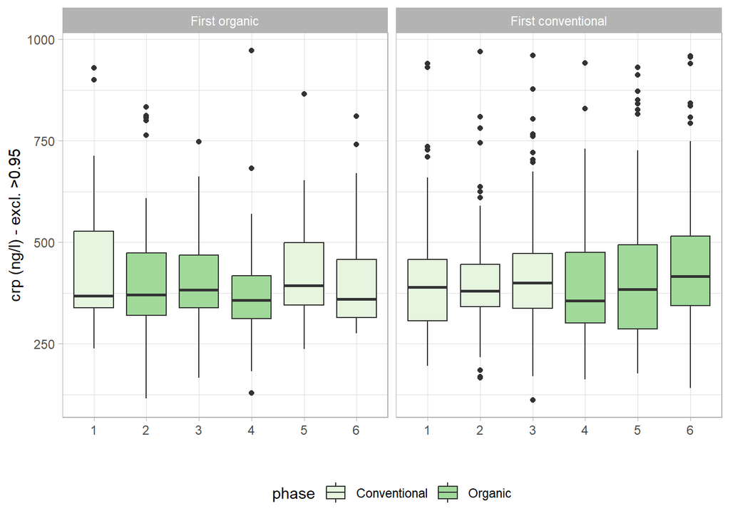

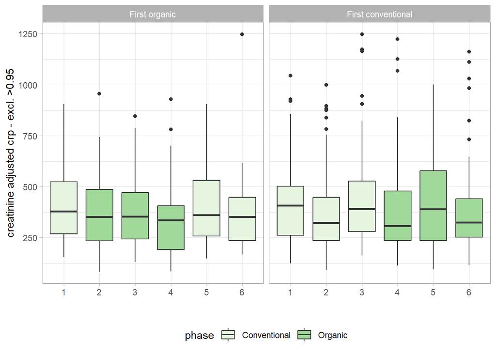

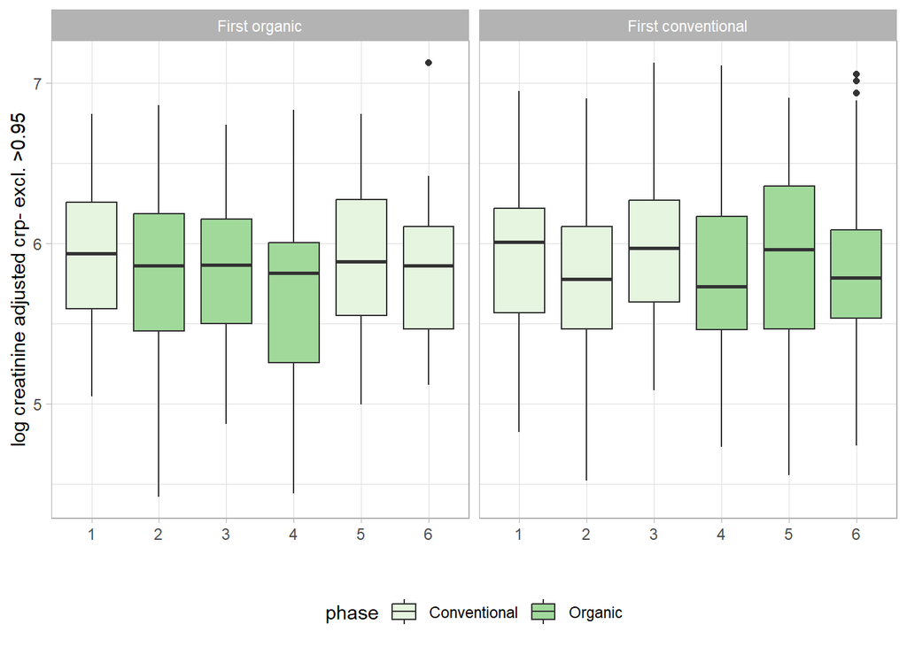